# Prosper LoanData

## Preliminary Wrangling

This document explores a dataset containing loan data for approximately 114000 loans .

```python
# import all packages and set plots to be embedded inline
import numpy as np
import pandas as pd
import matplotlib.pyplot as plt
import seaborn as sb

%matplotlib inline
sb.set_style("whitegrid")
```

```python
# load loan in the dataset into a pandas dataframe, print statistics
loan_df = pd.read_csv('prosperLoanData.csv')
```

```python
# high-level overview of data shape and composition
print('Shape' , loan_df.shape)
loan_df.info()
```

```
Shape (113937, 81)
<class 'pandas.core.frame.DataFrame'>
RangeIndex: 113937 entries, 0 to 113936
Data columns (total 81 columns):
 #   Column                               Non-Null Count   Dtype
---  ------                               --------------   -----
 0   ListingKey                           113937 non-null  object
 1   ListingNumber                        113937 non-null  int64
 2   ListingCreationDate                  113937 non-null  object
 3   CreditGrade                          28953 non-null   object
 4   Term                                 113937 non-null  int64
 5   LoanStatus                           113937 non-null  object
 6   ClosedDate                           55089 non-null   object
 7   BorrowerAPR                          113912 non-null  float64
 8   BorrowerRate                         113937 non-null  float64
```

[output cut: 74 more lines]

```python
# select some columns instead of total original columns number(81)
new_cols = ['ListingNumber','ListingCreationDate','Term','LoanStatus','BorrowerAPR','ListingCategory (numeric)',
            'BorrowerState','Occupation','EmploymentStatus','LoanOriginalAmount','StatedMonthlyIncome','DebtToIncomeRatio',
            'MonthlyLoanPayment']
loan2 = loan_df[new_cols]
```

```python
loan2.info()
```

```
<class 'pandas.core.frame.DataFrame'>
RangeIndex: 113937 entries, 0 to 113936
Data columns (total 13 columns):
 #   Column                     Non-Null Count   Dtype
---  ------                     --------------   -----
 0   ListingNumber              113937 non-null  int64
 1   ListingCreationDate        113937 non-null  object
 2   Term                       113937 non-null  int64
 3   LoanStatus                 113937 non-null  object
 4   BorrowerAPR                113912 non-null  float64
 5   ListingCategory (numeric)  113937 non-null  int64
 6   BorrowerState              108422 non-null  object
 7   Occupation                 110349 non-null  object
 8   EmploymentStatus           111682 non-null  object
 9   LoanOriginalAmount         113937 non-null  int64
 10  StatedMonthlyIncome        113937 non-null  float64
 11  DebtToIncomeRatio          105383 non-null  float64
 12  MonthlyLoanPayment         113937 non-null  float64
dtypes: float64(4), int64(4), object(5)
memory usage: 11.3+ MB
```

```python
# Check Duplicated Columns
loan2.duplicated().sum()
```

```
871
```

```python
# Drop Duplicated rows
loan2.drop_duplicates(inplace=True)
# check
print(loan2.duplicated().sum())
```

```
0
```

```python
loan2.isna().sum()
```

```
ListingNumber                   0
ListingCreationDate             0
Term                            0
LoanStatus                      0
BorrowerAPR                    25
ListingCategory (numeric)       0
BorrowerState                5515
Occupation                   3529
EmploymentStatus             2255
LoanOriginalAmount              0
StatedMonthlyIncome             0
DebtToIncomeRatio            8472
MonthlyLoanPayment              0
dtype: int64
```

```python
# Drop all rows with DebtToIncomeRatio is null
loan2 = loan2[loan2['DebtToIncomeRatio'].notnull()]
# drop all unknown state to visualize pure and fair plots
loan2 = loan2[loan2['BorrowerState'].notnull()]
```

```python
# fill null Occupation and EmploymentStatus
loan2['Occupation'].fillna(value='Other',inplace=True)
loan2['EmploymentStatus'].fillna(value='Not available',inplace=True)
# check
loan2.isna().sum()
```

```
ListingNumber                0
ListingCreationDate          0
Term                         0
LoanStatus                   0
BorrowerAPR                  0
ListingCategory (numeric)    0
BorrowerState                0
Occupation                   0
EmploymentStatus             0
LoanOriginalAmount           0
StatedMonthlyIncome          0
DebtToIncomeRatio            0
MonthlyLoanPayment           0
dtype: int64
```

```python
# check
loan2.isna().sum()
```

```
ListingNumber                0
ListingCreationDate          0
Term                         0
LoanStatus                   0
BorrowerAPR                  0
ListingCategory (numeric)    0
BorrowerState                0
Occupation                   0
EmploymentStatus             0
LoanOriginalAmount           0
StatedMonthlyIncome          0
DebtToIncomeRatio            0
MonthlyLoanPayment           0
dtype: int64
```

```python
# cretate new columns for category as name not numaric
new_vals ={0:'Not Available', 1:'Debt Consolidation', 2:'Home Improvement', 3:'Business', 4:'Personal Loan', 5 :'Student Use', 6:'Auto',
           7:'Other', 8:'Baby&Adoption', 9:'Boat', 10:'Cosmetic Procedure', 11:'Engagement Ring',12:'Green Loans',
           13:'Household Expenses', 14:'Large Purchases', 15:'Medical/Dental', 16:'Motorcycle', 17:'RV', 18:'Taxes',
           19:'Vacation', 20:'Wedding Loans'}
loan2['ListingCategory'] = loan2['ListingCategory (numeric)'].replace(new_vals)
```

```python
loan2['ListingCreationDate'] = pd.to_datetime(loan2['ListingCreationDate'])
loan2['month'] = loan2['ListingCreationDate'].dt.strftime('%b')
```

```python
# month into ordered categorical types
# Because there are only 3 types of term then this column is ordered categorical type
#Use Function to minimize the code and reusing
def Parscat ( column , array):
    order_cat = pd.api.types.CategoricalDtype(ordered = True,categories = array)
    loan2[column] = loan2[column].astype(order_cat)


months = ['Jan','Feb','Mar','Apr','May','Jun','Jul','Aug','Sep','Oct','Nov','Dec']
terms = [12 ,36 ,60 ]
Parscat('month' , months)
Parscat('Term',terms)
```

```python
loan2.info()
```

```
<class 'pandas.core.frame.DataFrame'>
Int64Index: 99151 entries, 0 to 113936
Data columns (total 15 columns):
 #   Column                     Non-Null Count  Dtype
---  ------                     --------------  -----
 0   ListingNumber              99151 non-null  int64
 1   ListingCreationDate        99151 non-null  datetime64[ns]
 2   Term                       99151 non-null  category
 3   LoanStatus                 99151 non-null  object
 4   BorrowerAPR                99151 non-null  float64
 5   ListingCategory (numeric)  99151 non-null  int64
 6   BorrowerState              99151 non-null  object
 7   Occupation                 99151 non-null  object
 8   EmploymentStatus           99151 non-null  object
 9   LoanOriginalAmount         99151 non-null  int64
 10  StatedMonthlyIncome        99151 non-null  float64
 11  DebtToIncomeRatio          99151 non-null  float64
 12  MonthlyLoanPayment         99151 non-null  float64
 13  ListingCategory            99151 non-null  object
 14  month                      99151 non-null  category
dtypes: category(2), datetime64[ns](1), float64(4), int64(3), object(5)
memory usage: 10.8+ MB
```

```python
# descriptive statistics for numeric variables
print(loan2.shape)
loan2.describe()
```

```
(99151, 15)
```

|  | ListingNumber | BorrowerAPR | ListingCategory (numeric) | LoanOriginalAmount | StatedMonthlyIncome | DebtToIncomeRatio | MonthlyLoanPayment |
| --- | --- | --- | --- | --- | --- | --- | --- |
| count | 9.915100e+04 | 99151.000000 | 99151.000000 | 99151.000000 | 99151.000000 | 99151.000000 | 99151.000000 |
| mean | 6.524123e+05 | 0.217751 | 2.869875 | 8587.378846 | 5694.758923 | 0.273312 | 278.491379 |
| std | 3.136990e+05 | 0.080025 | 4.055171 | 6352.556218 | 4960.961407 | 0.510596 | 194.296414 |
| min | 6.537000e+03 | 0.006530 | 0.000000 | 1000.000000 | 0.000000 | 0.000000 | 0.000000 |
| 25% | 4.458155e+05 | 0.155385 | 1.000000 | 4000.000000 | 3333.333333 | 0.150000 | 135.820000 |
| 50% | 6.191710e+05 | 0.208080 | 1.000000 | 7000.000000 | 4833.333333 | 0.220000 | 226.820000 |
| 75% | 9.085950e+05 | 0.280780 | 3.000000 | 12000.000000 | 6916.666667 | 0.320000 | 377.655000 |
| max | 1.255149e+06 | 0.423950 | 20.000000 | 35000.000000 | 483333.333333 | 10.010000 | 2251.510000 |

```python
loan2.head()
```

|  | ListingNumber | ListingCreationDate | Term | LoanStatus | BorrowerAPR | ListingCategory (numeric) | BorrowerState | Occupation | EmploymentStatus | LoanOriginalAmount | StatedMonthlyIncome | DebtToIncomeRatio | MonthlyLoanPayment | ListingCategory | month |
| --- | --- | --- | --- | --- | --- | --- | --- | --- | --- | --- | --- | --- | --- | --- | --- |
| 0 | 193129 | 2007-08-26 19:09:29.263 | 36 | Completed | 0.16516 | 0 | CO | Other | Self-employed | 9425 | 3083.333333 | 0.17 | 330.43 | Not Available | Aug |
| 1 | 1209647 | 2014-02-27 08:28:07.900 | 36 | Current | 0.12016 | 2 | CO | Professional | Employed | 10000 | 6125.000000 | 0.18 | 318.93 | Home Improvement | Feb |
| 2 | 81716 | 2007-01-05 15:00:47.090 | 36 | Completed | 0.28269 | 0 | GA | Other | Not available | 3001 | 2083.333333 | 0.06 | 123.32 | Not Available | Jan |
| 3 | 658116 | 2012-10-22 11:02:35.010 | 36 | Current | 0.12528 | 16 | GA | Skilled Labor | Employed | 10000 | 2875.000000 | 0.15 | 321.45 | Motorcycle | Oct |
| 4 | 909464 | 2013-09-14 18:38:39.097 | 36 | Current | 0.24614 | 2 | MN | Executive | Employed | 15000 | 9583.333333 | 0.26 | 563.97 | Home Improvement | Sep |

```python
# save cleaned data stset to use it in the part 2
# to avoid recleane it again :)
loan2.to_csv('cln_prosperLoanData.csv')
```

### What is the structure of your dataset?

There are 99,151 loans data in the dataset with 14 features (ListingNumber, ListingCreationDate, Term, LoanStatus, BorrowerAPR, ListingCategory (numeric), BorrowerState, Occupation', 'EmploymentStatus', LoanOriginalAmount, StatedMonthlyIncome, DebtToIncomeRatio, MonthlyLoanPayment, ListingCategory).

### What are the main features of interest in your dataset?

I'm most interested in figuring out what features are best for predicting the Loan Amount in the dataset. and Borrower APR.

### What features in the dataset do you think will help support your investigation into your features of interest?

I expect that MonthlyLoanPayment and StatedMonthlyIncome will impact on the loan amount, and in Borrower APR, I expected that the Borrower APR be affected by loan amount and term.

## Univariate Exploration

the distribution of loans amount and BorrowerAPR Distribution

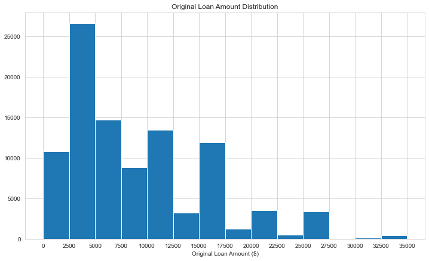

```python
plt.figure(figsize = [12, 7])
bins = np.arange(0,loan2['LoanOriginalAmount'].max()+1000,2500)
plt.hist(data=loan2,x='LoanOriginalAmount',bins=bins)
plt.title('Original Loan Amount Distribution')
plt.xlabel('Original Loan Amount ($)')
plt.xticks(bins);
```

I'll now move on to the other variable in the dataset: Borrower APR to show the distribution

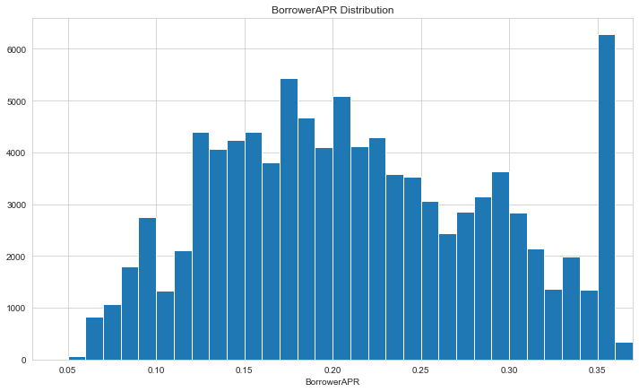

```python
plt.figure(figsize = [12, 7])
bins = np.arange(0, loan2['BorrowerAPR'].max()+0.5 , 0.01)
plt.hist(data=loan2,x='BorrowerAPR', bins= bins)
plt.title('BorrowerAPR Distribution')
plt.xlabel('BorrowerAPR')
plt.xlim((0.03,0.37));
```

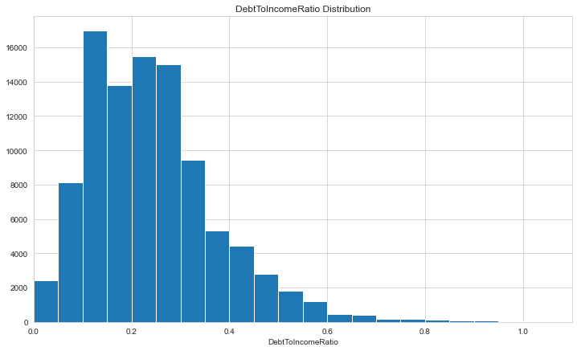

```python
plt.figure(figsize = [12, 7])
bins = np.arange(0,loan2['DebtToIncomeRatio'].max()+0.1 , 0.05 )
plt.hist(data=loan2,x='DebtToIncomeRatio',bins=bins)
plt.title('DebtToIncomeRatio Distribution')
plt.xlabel('DebtToIncomeRatio')
plt.xlim((0,1.1));
```

I'll now look at the other features in the data to see if any of them hold interesting properties.

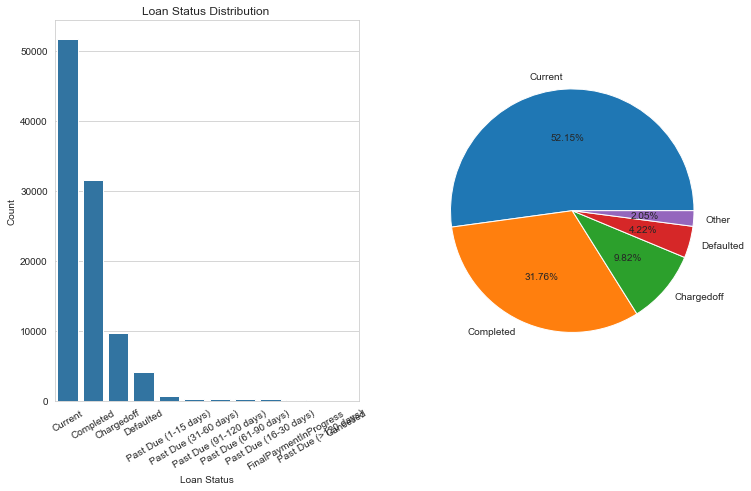

```python
base_color = sb.color_palette()[0]
orderit = loan2['LoanStatus'].value_counts()
plt.figure(figsize = [12, 7])
plt.subplot(1,2,1)
sb.countplot(data=loan2,x='LoanStatus',order=orderit.index,color=base_color)
plt.title('Loan Status Distribution ')
plt.xlabel('Loan Status')
plt.ylabel('Count',)
plt.xticks(rotation=30);
plt.subplot(1,2,2)
# create list that contain the loan status only
top_status = loan2['LoanStatus']
# replace some labels with other to decrease the clutter
top_status = top_status.replace(orderit.index[4:],'Other')
pie_order= top_status.value_counts()
plt.pie(pie_order,autopct='%1.2f%%',labels=pie_order.index);
```

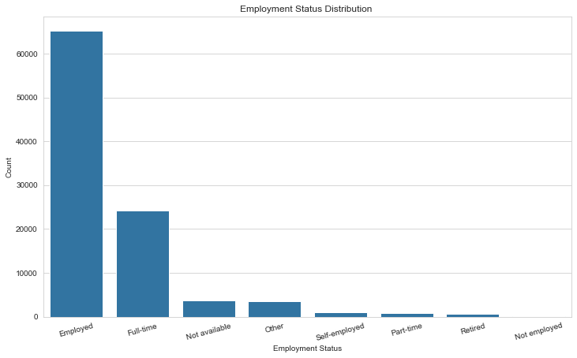

```python
orderit = loan2['EmploymentStatus'].value_counts().index
plt.figure(figsize = [12, 7])
sb.countplot(data=loan2,x='EmploymentStatus',order=orderit,color=base_color)
plt.title('Employment Status Distribution ')
plt.xlabel('Employment Status')
plt.ylabel('Count')
plt.xticks(rotation=15);
```

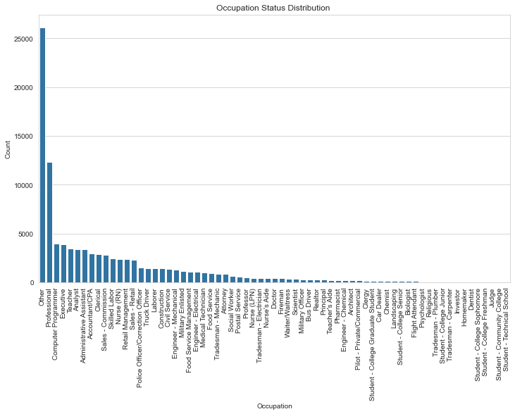

```python
plt.figure(figsize = [12, 7])
orderit = loan2['Occupation'].value_counts().index
sb.countplot(data=loan2,x='Occupation',order=orderit,color=base_color)
plt.title('Occupation Status Distribution ')
plt.xlabel('Occupation')
plt.ylabel('Count')
plt.xticks(rotation=90);
```

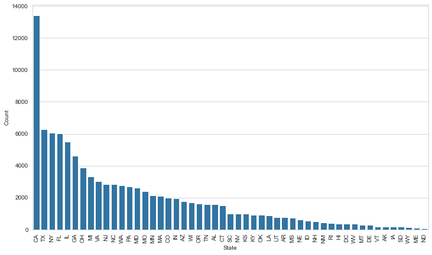

```python
plt.figure(figsize = [12, 7])
orderit = loan2['BorrowerState'].value_counts().index
sb.countplot(data=loan2,x='BorrowerState',order=orderit,color=base_color)
plt.xlabel('State')
plt.ylabel('Count')
plt.xticks(rotation=90);
```

In the First plot we notice that most of the loan status are current and the second status is completed, in the second plot, we notice that the most client are employed and full time, in the third, the student's community are the least taking loan, and in the last plot, the California state is the most take loans and in another hand side, the least state is North Dakota.

```python
numeric_vars = ['BorrowerAPR','LoanOriginalAmount','StatedMonthlyIncome','DebtToIncomeRatio','MonthlyLoanPayment']
categoric_vars = ['Term','LoanStatus','BorrowerState','Occupation','EmploymentStatus','ListingCategory']
```

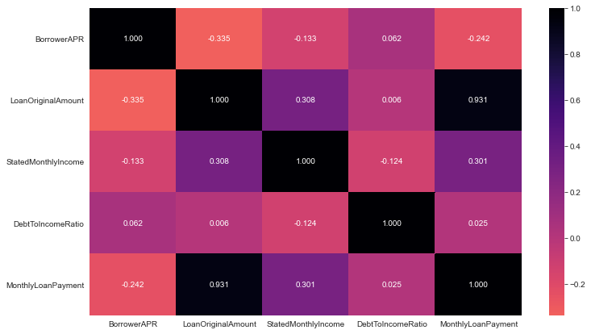

```python
# correlation plot
plt.figure(figsize = [12, 7])
sb.heatmap(loan2[numeric_vars].corr(), annot = True, fmt = '.3f',
           cmap = 'magma_r', center = 0)
plt.show()
```

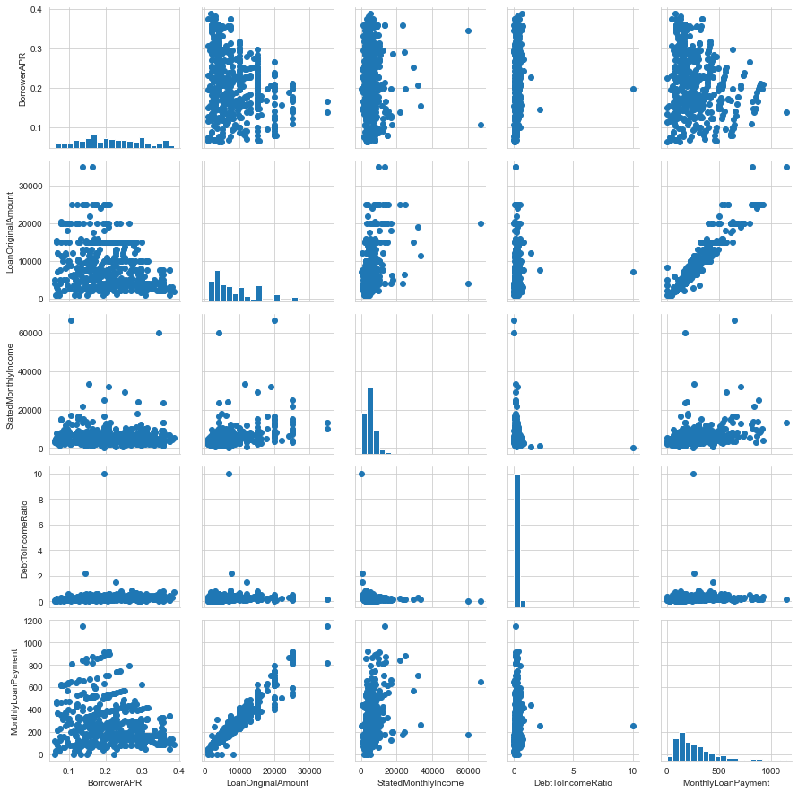

```python
# plot matrix: sample 500 diamonds so that plots are clearer and
# they render faster
sample = loan2.sample(n=500, replace = False)
g = sb.PairGrid(data = sample, vars = numeric_vars)
g = g.map_diag(plt.hist, bins = 20);
g.map_offdiag(plt.scatter);
```

As expected, the loan original amount is highly correlated with Monthly loan payment (0.931), which means when you take a huge loan then you will pay more. and threre are a realtions Between StatedMonthlyIncome and both Monthly loan payment and loan original amount.(0.301 and 0.308 Respectively). and we can see there is a negative relateion between BorrowerAPR and LoanOriginalAmount (0.-335).

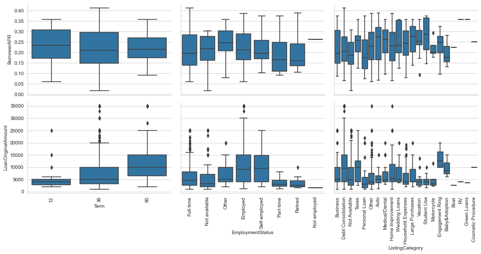

```python
# plot matrix of numeric features against categorical features.
# can use a larger sample since there are fewer plots and they're simpler in nature.

sample = loan2.sample(n=2000, replace = False)

def boxgrid(x, y, **kwargs):
    """ Quick hack for creating box plots with seaborn's PairGrid. """
    default_color = sb.color_palette()[0]
    sb.boxplot(x, y, color = default_color)
    plt.xticks(rotation=90)
box_cat = ['Term','EmploymentStatus','ListingCategory']
plt.figure(figsize = [10, 20])
g = sb.PairGrid(data = sample, y_vars = ['BorrowerAPR', 'LoanOriginalAmount'], x_vars = box_cat,
                height = 3, aspect = 1.5)
g.map(boxgrid)
plt.show();
```

Analysis

1. Borrowe APR
   - Term

     ```
       Most ARP for 36 months loans
     ```

   - Employment Status

     ```
       If we avoid other and not available classes we can say most clients are employed and retired.
     ```

   - Listing Category

2. Loan Original Amount
   - Term

     ```
       When the amount increases, the increase is in the term
     ```

   - Employment Status

     ```
       Employed Client is the most class are taking the loans
     ```

   - Listing Category

Finally, let's look at relationships the three categorical features.

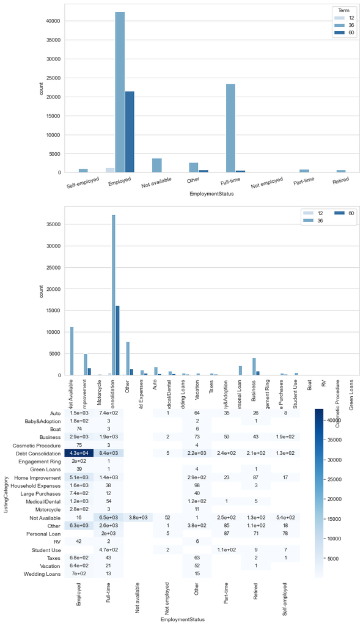

```python
# since there's only three subplots to create, using the full data should be fine.
plt.figure(figsize = [10, 20])

# subplot 1: EmploymentStatus vs Term
plt.subplot(3, 1, 1)
sb.countplot(data = loan2, x = 'EmploymentStatus', hue = 'Term', palette = 'Blues')
plt.xticks(rotation = 15);
# subplot 2: ListingCategory vs. Term
ax = plt.subplot(3, 1, 2)
sb.countplot(data = loan2, x = 'ListingCategory', hue = 'Term', palette = 'Blues')
ax.legend(ncol = 2) # re-arrange legend to reduce overlapping
plt.xticks(rotation = 90);

# subplot 2: ListingCategory vs. EmploymentStatus
#Because there are a lot of categories in both variable I prefer to use the heatmap
ax = plt.subplot(3, 1, 3)
ct_count =loan2.groupby(['ListingCategory','EmploymentStatus']).size()
ct_count = ct_count.reset_index(name='count')
ct_count = ct_count.pivot(index ='ListingCategory' , columns= 'EmploymentStatus',values='count' )
sb.heatmap(ct_count,annot=True,cmap="Blues")
plt.show()
```

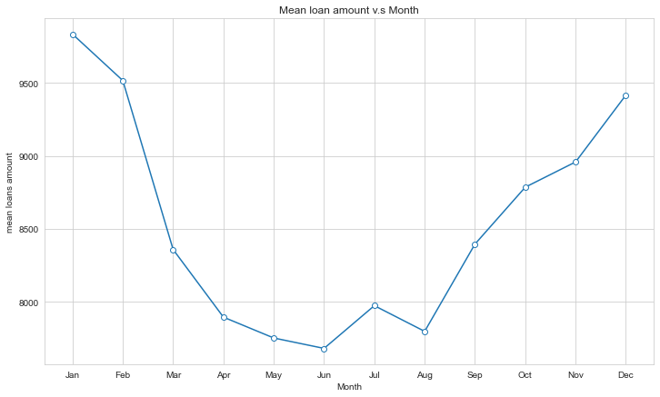

```python
# mean loan amount vs month
line = loan2.groupby('month')['LoanOriginalAmount'].mean()
plt.figure(figsize = [12, 7])
line.plot(marker="o",markerfacecolor='white')
plt.title('Mean loan amount v.s Month')
plt.ylabel('mean loans amount')
plt.xlabel('Month')
plt.xticks(np.arange(0,12,1),labels= months); # to show all months name
```

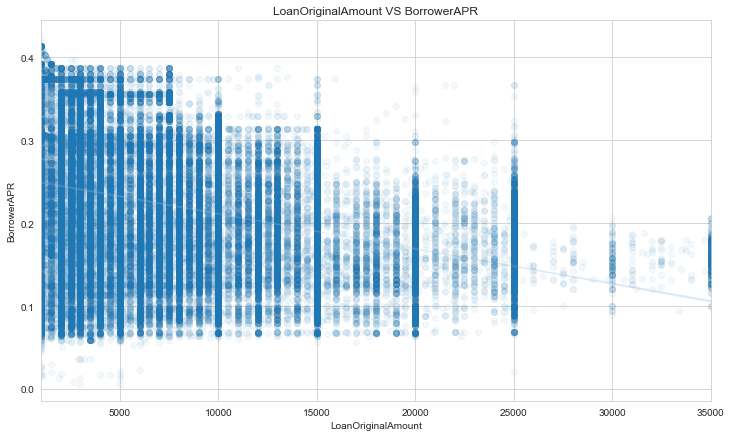

```python
plt.figure(figsize = [12, 7])
sb.regplot(data = loan2, x = 'LoanOriginalAmount', y = 'BorrowerAPR',scatter_kws={'alpha':0.05})
plt.title('LoanOriginalAmount VS BorrowerAPR')
plt.xlabel('LoanOriginalAmount')
plt.ylabel('BorrowerAPR');
```

The Plotting Loan amount and its relation with Borrower APR is a negative relationship when an increase in loan amount the decrease in borrower's annual percentage rate. And we see a huge range for rate values in Borrower ARP for the approximately same amount.

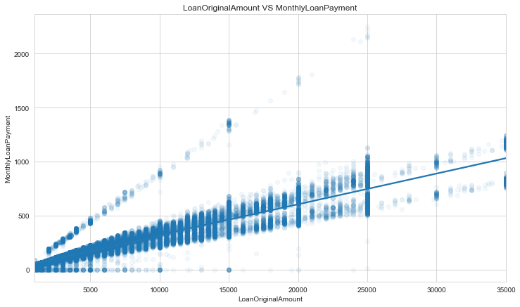

```python
plt.figure(figsize = [12, 7])
sb.regplot(data = loan2, x = 'LoanOriginalAmount', y = 'MonthlyLoanPayment',scatter_kws={'alpha':0.05})
plt.title('LoanOriginalAmount VS MonthlyLoanPayment')
plt.xlabel('LoanOriginalAmount')
plt.ylabel('MonthlyLoanPayment');
```

The Plotting Loan amount and its relation with MonthlyLoanPayment is a strong positive relationship when an increase in loan amount the increase in payment per month and its look like the monthly loan payment are dependent on the amount.

### How did the feature(s) of interest vary with other features in the dataset?

The borrower APR is negatively correlated with the loan original amount, that when an increase in loan amount the decrease in borrower annual percentage rate. It also shows that at different size of the loan amount, the APR has a large range, but the range of APR decrease with the increase of loan amount.

## Multivariate Exploration

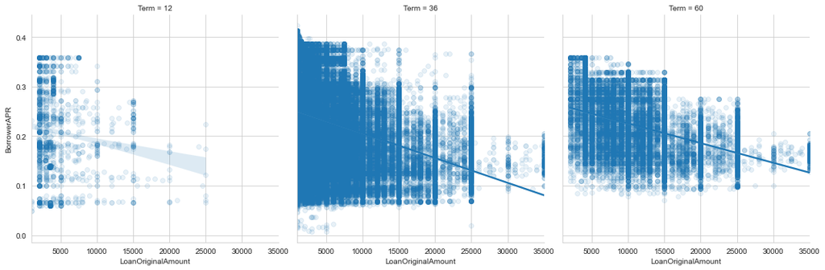

```python
#Term and the impact on loan amount and borrower APR  relationship
# used col rather than hue to split the plot into 3
g = sb.FacetGrid(data = loan2, col = 'Term', height = 5)
g.map(sb.regplot, 'LoanOriginalAmount', 'BorrowerAPR',scatter_kws={'alpha':0.1});
```

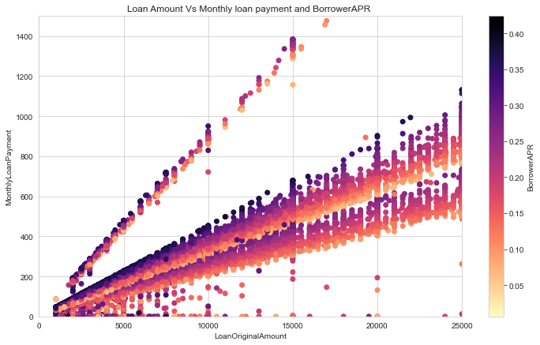

```python
plt.figure(figsize = [12, 7])
plt.scatter(data = loan2, x = 'LoanOriginalAmount', y = 'MonthlyLoanPayment', c = 'BorrowerAPR',
            cmap = 'magma_r')
plt.colorbar(label='BorrowerAPR')
# to Zoom the plot
plt.xlim((0,25000))
plt.ylim((0,1500))
plt.title('Loan Amount Vs Monthly loan payment and BorrowerAPR ')
plt.xlabel('LoanOriginalAmount')
plt.ylabel('MonthlyLoanPayment');
```

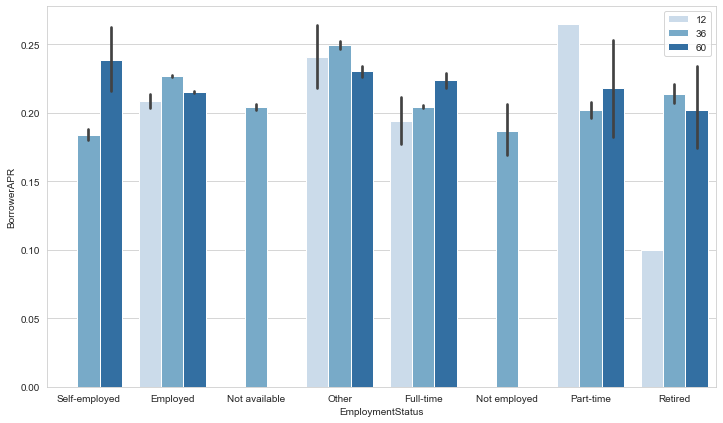

```python
plt.figure(figsize = [12, 7])
sb.barplot(data = loan2 , x='EmploymentStatus',y='BorrowerAPR' , hue = 'Term',palette='Blues')
plt.legend ();
```

there are a fewer loan of term 12 and more of term 36

### Were there any interesting or surprising interactions between features?

A surprising interaction is that the borrower APR and loan amount is negatively correlated and I was shocked by the result of plot #2 (Loan Amount Vs Monthly loan payment and BorrowerAPR impact)because I know if you pay more per month, then you will pay off the loan more quickly so APR is less.